# Reglas de asociación con Titanic

Preprocesamiento de datos con el dataset [titanic](https://www.kaggle.com/c/titanic/).

> El hundimiento del Titanic es una de las tragedias marítimas más conocidas de la historia. El 15 de abril de 1912, durante su viaje inaugural, el Titanic se hundió después de chocar contra un iceberg. En el accidente murieron 1502 personas de las 2224 que habían embarcado, inluyendo pasajeros y tripulación. Una de las razones por las que no se encontraron más supervivientes fue la falta de espacio en los barcos salvavidas. Así, aunque la suerte sin duda sonrió a los supervivientes, también resultaron más favorecidos algunos grupos de personas, como las mujeres, los niños y los pasajeros de la clase superior.

**En este problema analizaremos qué tipos de personas tuvieron más probabilidades de sobrevivir. Para ello, aplicaremos extracción de reglas de asociación que nos permitirán conocer las características de los pasajeros sobrevivieron al hundimiento.**

# Lectura y preprocesamiento de los datos

## Carga de datos

Comenzaremos utilizando el fichero [*titanic*](https://www.kaggle.com/c/titanic/data) de Kaggle, donde encontramos los datos de 891 pasajeros y que utilizaremos para extraer reglas.

Para lectura de datos, utilizaremos alguna de las variantes de la función [`read`](http://r4ds.had.co.nz/data-import.html). A continuación, podemos inspeccionar el contenido de la tabla de datos, que se almacena en formato [`tibble`](http://r4ds.had.co.nz/tibbles.html).

```r
datos <- read_csv('titanic.csv')
datos
```

| PassengerId | Survived | Pclass | Name | Sex | Age | SibSp | Parch | Ticket | Fare | Cabin | Embarked |
| --- | --- | --- | --- | --- | --- | --- | --- | --- | --- | --- | --- |
| 1 | 0 | 3 | Braund, Mr. Owen Harris | male | 22.00 | 1 | 0 | A/5 21171 | 7.2500 | NA | S |
| 2 | 1 | 1 | Cumings, Mrs. John Bradley (Florence Briggs Thayer) | female | 38.00 | 1 | 0 | PC 17599 | 71.2833 | C85 | C |
| 3 | 1 | 3 | Heikkinen, Miss. Laina | female | 26.00 | 0 | 0 | STON/O2. 3101282 | 7.9250 | NA | S |
| 4 | 1 | 1 | Futrelle, Mrs. Jacques Heath (Lily May Peel) | female | 35.00 | 1 | 0 | 113803 | 53.1000 | C123 | S |
| 5 | 0 | 3 | Allen, Mr. William Henry | male | 35.00 | 0 | 0 | 373450 | 8.0500 | NA | S |
| 6 | 0 | 3 | Moran, Mr. James | male | NA | 0 | 0 | 330877 | 8.4583 | NA | Q |
| 7 | 0 | 1 | McCarthy, Mr. Timothy J | male | 54.00 | 0 | 0 | 17463 | 51.8625 | E46 | S |
| 8 | 0 | 3 | Palsson, Master. Gosta Leonard | male | 2.00 | 3 | 1 | 349909 | 21.0750 | NA | S |
| 9 | 1 | 3 | Johnson, Mrs. Oscar W (Elisabeth Vilhelmina Berg) | female | 27.00 | 0 | 2 | 347742 | 11.1333 | NA | S |
| 10 | 1 | 2 | Nasser, Mrs. Nicholas (Adele Achem) | female | 14.00 | 1 | 0 | 237736 | 30.0708 | NA | C |

[output cut: 881 more lines]

## Estado de los datos

Podemos identificar los valores perdidos de la tabla utilizando `df_status()`, del paquete [`funModeling`](https://livebook.datascienceheroes.com/exploratory-data-analysis.html#dataset-health-status).

```r
df_status(datos)
```

```
##       variable q_zeros p_zeros q_na  p_na q_inf p_inf      type unique
## 1  PassengerId       0    0.00    0  0.00     0     0   numeric    891
## 2     Survived     549   61.62    0  0.00     0     0   numeric      2
## 3       Pclass       0    0.00    0  0.00     0     0   numeric      3
## 4         Name       0    0.00    0  0.00     0     0 character    891
## 5          Sex       0    0.00    0  0.00     0     0 character      2
## 6          Age       0    0.00  177 19.87     0     0   numeric     88
## 7        SibSp     608   68.24    0  0.00     0     0   numeric      7
## 8        Parch     678   76.09    0  0.00     0     0   numeric      7
## 9       Ticket       0    0.00    0  0.00     0     0 character    681
## 10        Fare      15    1.68    0  0.00     0     0   numeric    248
## 11       Cabin       0    0.00  687 77.10     0     0 character    147
## 12    Embarked       0    0.00    2  0.22     0     0 character      3
```

Algunas observaciones interesantes:

- Los valores de *PassengerId* y *Name* son únicos
- Existen dos valores diferentes para *Survived*
- No sobrevivieron 549 pasajeros (61.62%)
- Aparecen numerosos valores perdidos (*na*) en las variables *Age* y *Cabin*
- La mayor parte de los atributos son numéricos

## Selección de variables y valores perdidos

Para realizar nuestro análisis no necesitamos todas las variables; nos interesan solamente varias de ellas que *sospechamos* que pueden ser de utilidad:

- `Pclass`: clase del barco en que viajaba el pasajero (1, 2, 3)
- `Age`: edad del pasajero (0, 100)
- `Sex`: sexo del pasajero (male, female)
- `Survived`: sobrevivió o no (1, 0)

Por lo tanto, podemos seleccionar solo las que nos interesan:

```r
datos_seleccion <- datos %>%
  select(Pclass, Age, Sex, Survived)
datos_seleccion
```

| Pclass | Age | Sex | Survived |
| --- | --- | --- | --- |
| 3 | 22.00 | male | 0 |
| 1 | 38.00 | female | 1 |
| 3 | 26.00 | female | 1 |
| 1 | 35.00 | female | 1 |
| 3 | 35.00 | male | 0 |
| 3 | NA | male | 0 |
| 1 | 54.00 | male | 0 |
| 3 | 2.00 | male | 0 |
| 3 | 27.00 | female | 1 |
| 2 | 14.00 | female | 1 |

[output cut: 881 more lines]

Podemos obviar las filas que contienen valores perdidos con `drop_na()`. También podrían aplicarse otros procedimientos más sofisticados para tratar con esos valores perdidos (ver paquete [`mice`](https://cran.r-project.org/web/packages/mice/index.html).

```r
datos_seleccion <- datos_seleccion %>%
  drop_na()
datos_seleccion
```

| Pclass | Age | Sex | Survived |
| --- | --- | --- | --- |
| 3 | 22.00 | male | 0 |
| 1 | 38.00 | female | 1 |
| 3 | 26.00 | female | 1 |
| 1 | 35.00 | female | 1 |
| 3 | 35.00 | male | 0 |
| 1 | 54.00 | male | 0 |
| 3 | 2.00 | male | 0 |
| 3 | 27.00 | female | 1 |
| 2 | 14.00 | female | 1 |
| 3 | 4.00 | female | 1 |

[output cut: 704 more lines]

## Recodificación y discretización de variables

```r
# Survived
datos_cuantitativos <- datos_seleccion %>%
  mutate(Survived = ifelse(Survived == 0, "no", "yes"))
```

```r
# Pclass
datos_cuantitativos <- datos_cuantitativos %>%
  mutate(Pclass = case_when(
    Pclass == 1 ~ '1st',
    Pclass == 2 ~ '2nd',
    Pclass == 3 ~ '3rd')
  )

# Age
datos_cuantitativos <- datos_cuantitativos %>%
  mutate(Age = case_when(
    Age >= 18 ~ 'adult',
    TRUE ~ 'child')
  )

datos_cuantitativos
```

| Pclass | Age | Sex | Survived |
| --- | --- | --- | --- |
| 3rd | adult | male | no |
| 1st | adult | female | yes |
| 3rd | adult | female | yes |
| 1st | adult | female | yes |
| 3rd | adult | male | no |
| 1st | adult | male | no |
| 3rd | child | male | no |
| 3rd | adult | female | yes |
| 2nd | child | female | yes |
| 3rd | child | female | yes |

[output cut: 704 more lines]

## Transformación a formato transaccional

Para ejecutar el algoritmos Apriori necesitamos convertir nuestra tabla a formato transaccional. En este problema, los ítems serán las características de los individuos expresadas en formato `<atributo=valor>`. Por ejemplo, la transacción correspondiente al primer individuo será:

`<Pclass=3rd>, <Age=adult>, <Sex=male>, <Survived=no>`

Para ello, necesitamos primero pasar todas las columnas a tipo de dato `factor`:

```r
datos_cuantitativos <- datos_cuantitativos %>%
  mutate_all(as.factor)
datos_cuantitativos
```

| Pclass | Age | Sex | Survived |
| --- | --- | --- | --- |
| 3rd | adult | male | no |
| 1st | adult | female | yes |
| 3rd | adult | female | yes |
| 1st | adult | female | yes |
| 3rd | adult | male | no |
| 1st | adult | male | no |
| 3rd | child | male | no |
| 3rd | adult | female | yes |
| 2nd | child | female | yes |
| 3rd | child | female | yes |

[output cut: 704 more lines]

Y, a continuación, convertir a `"transactions"` con la función `as()`:

```r
datost <- as(datos_cuantitativos, "transactions")
datost
```

```
## transactions in sparse format with
##  714 transactions (rows) and
##  9 items (columns)
```

```r
inspect(datost)
```

```
##       items                                          transactionID
## [1]   {Pclass=3rd,Age=adult,Sex=male,Survived=no}    1
## [2]   {Pclass=1st,Age=adult,Sex=female,Survived=yes} 2
## [3]   {Pclass=3rd,Age=adult,Sex=female,Survived=yes} 3
## [4]   {Pclass=1st,Age=adult,Sex=female,Survived=yes} 4
## [5]   {Pclass=3rd,Age=adult,Sex=male,Survived=no}    5
## [6]   {Pclass=1st,Age=adult,Sex=male,Survived=no}    6
## [7]   {Pclass=3rd,Age=child,Sex=male,Survived=no}    7
## [8]   {Pclass=3rd,Age=adult,Sex=female,Survived=yes} 8
## [9]   {Pclass=2nd,Age=child,Sex=female,Survived=yes} 9
## [10]  {Pclass=3rd,Age=child,Sex=female,Survived=yes} 10
## [11]  {Pclass=1st,Age=adult,Sex=female,Survived=yes} 11
## [12]  {Pclass=3rd,Age=adult,Sex=male,Survived=no}    12
## [13]  {Pclass=3rd,Age=adult,Sex=male,Survived=no}    13
## [14]  {Pclass=3rd,Age=child,Sex=female,Survived=no}  14
```

[output cut: 700 more lines]

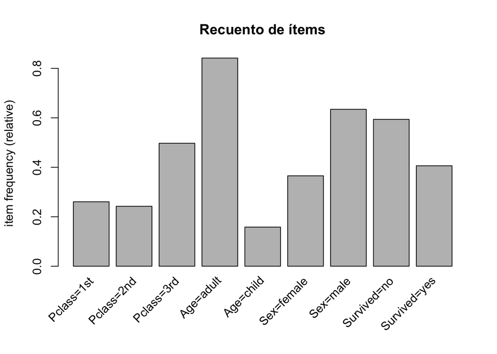

```r
itemFrequencyPlot(datost, type="relative", main="Recuento de ítems")
```

# Ejercicios